# Ecosystem Service Flood Control | Norway

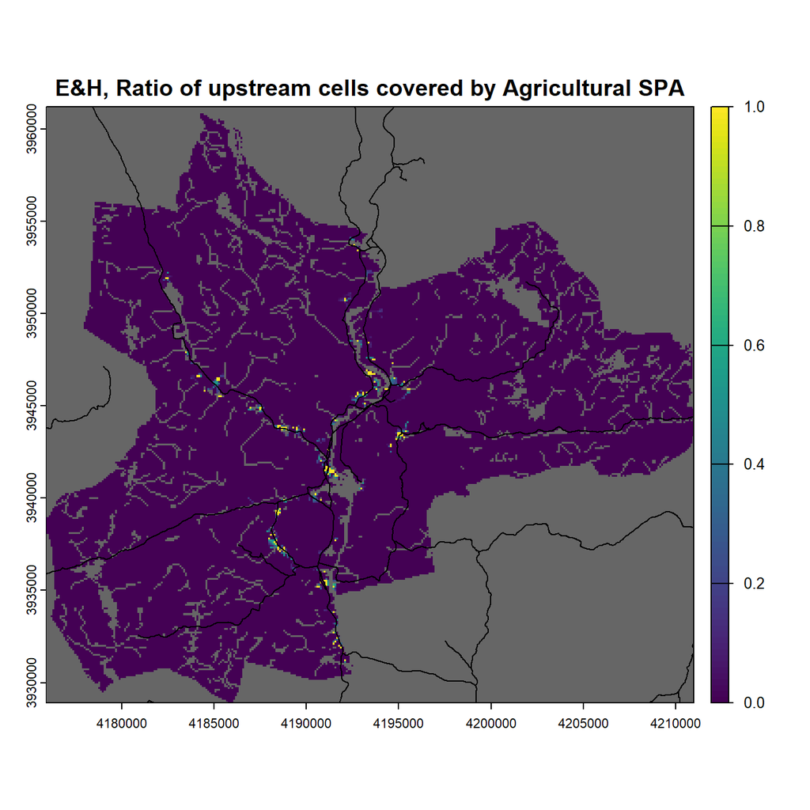

```r
plot(ratio_agric %>% crop(ehs,mask=T),colNA="grey40", main = "E&H, Ratio of upstream cells covered by Agricultural SPA")
plot(roads_t,add=T)
```

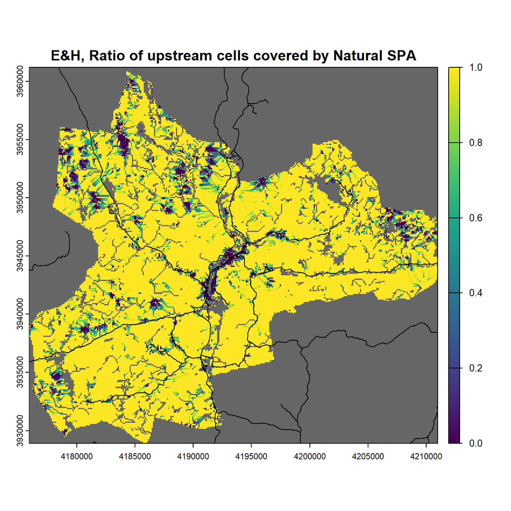

```r
plot(ratio_natur %>% crop(ehs,mask=T),colNA="grey40", main = "E&H, Ratio of upstream cells covered by Natural SPA")
plot(roads_t,add=T)
```

Now we have the ratios, so next we can compute for each service demanding area what the respective service flow is. We can make maps of it and also tables.

```r
## serice flow to meet demand by artificial area
flow_d_artif_s_artif<-sdam_artif*ratio_artif
flow_d_artif_s_agric<-sdam_artif*ratio_agric
flow_d_artif_s_natur<-sdam_artif*ratio_natur

## serice flow to meet demand by agricultural area
flow_d_agric_s_artif<-sdam_agric*ratio_artif
flow_d_agric_s_agric<-sdam_agric*ratio_agric
flow_d_agric_s_natur<-sdam_agric*ratio_natur

## serice flow to meet demand by population
flow_d_pop_s_artif<-sdam_pop*ratio_artif
flow_d_pop_s_agric<-sdam_pop*ratio_agric
flow_d_pop_s_natur<-sdam_pop*ratio_natur

## here add the aggregate ones econ and pop, and save those two as rasters.
flow_d_econ <- flow_d_artif_s_artif + flow_d_artif_s_agric + flow_d_artif_s_natur +
  flow_d_agric_s_artif + flow_d_agric_s_agric + flow_d_agric_s_natur

flow_d_pop <- flow_d_pop_s_artif + flow_d_pop_s_agric + flow_d_pop_s_natur

## save results as tif
rfp<-file.path("C:","Users","muk",
               paste0("OneDrive - Statistisk sentralbyr","\U00E5"),
               "Projects","Naturregnskap","Flomkontroll","Norway_R","output_maps")
writeRaster(flow_d_econ,file.path(rfp,"flow_d_econ.tif"),overwrite=T)
writeRaster(flow_d_pop,file.path(rfp,"flow_d_pop.tif"),overwrite=T)

# Make a table of values
flow_df<-as.data.frame(matrix(ncol=4,nrow=3))
colnames(flow_df)<-c("provision_cat","demand_artif","demand_agric","demand_pop")
flow_df$provision_cat<-c("artif","agric","natur")

flow_df$demand_artif[flow_df$provision_cat=="artif"]<-sum(values(flow_d_artif_s_artif),na.rm=T)
flow_df$demand_artif[flow_df$provision_cat=="agric"]<-sum(values(flow_d_artif_s_agric),na.rm=T)
flow_df$demand_artif[flow_df$provision_cat=="natur"]<-sum(values(flow_d_artif_s_natur),na.rm=T)

flow_df$demand_agric[flow_df$provision_cat=="artif"]<-sum(values(flow_d_agric_s_artif),na.rm=T)
flow_df$demand_agric[flow_df$provision_cat=="agric"]<-sum(values(flow_d_agric_s_agric),na.rm=T)
flow_df$demand_agric[flow_df$provision_cat=="natur"]<-sum(values(flow_d_agric_s_natur),na.rm=T)

flow_df$demand_pop[flow_df$provision_cat=="artif"]<-sum(values(flow_d_pop_s_artif),na.rm=T)
flow_df$demand_pop[flow_df$provision_cat=="agric"]<-sum(values(flow_d_pop_s_agric),na.rm=T)
flow_df$demand_pop[flow_df$provision_cat=="natur"]<-sum(values(flow_d_pop_s_natur),na.rm=T)
```

Let’s take a look at the flows for Evje and Hornnes.

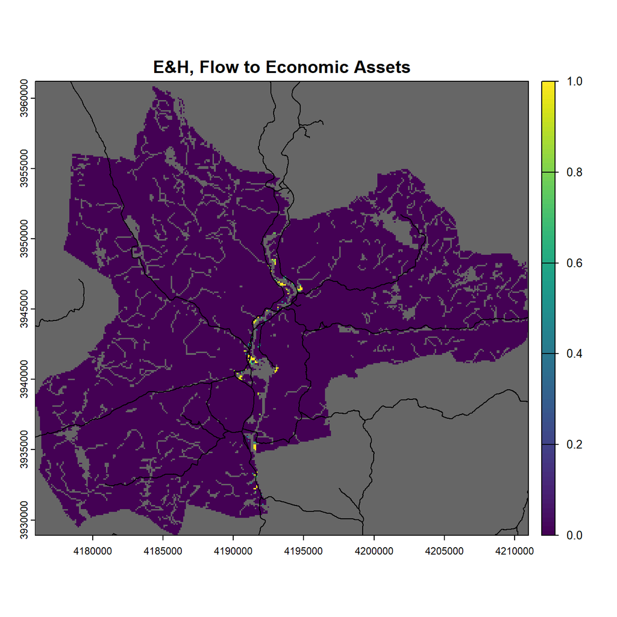

```r
plot(flow_d_econ %>% crop(ehs,mask=T),colNA="grey40", main = "E&H, Flow to Economic Assets")
plot(roads_t,add=T)
```

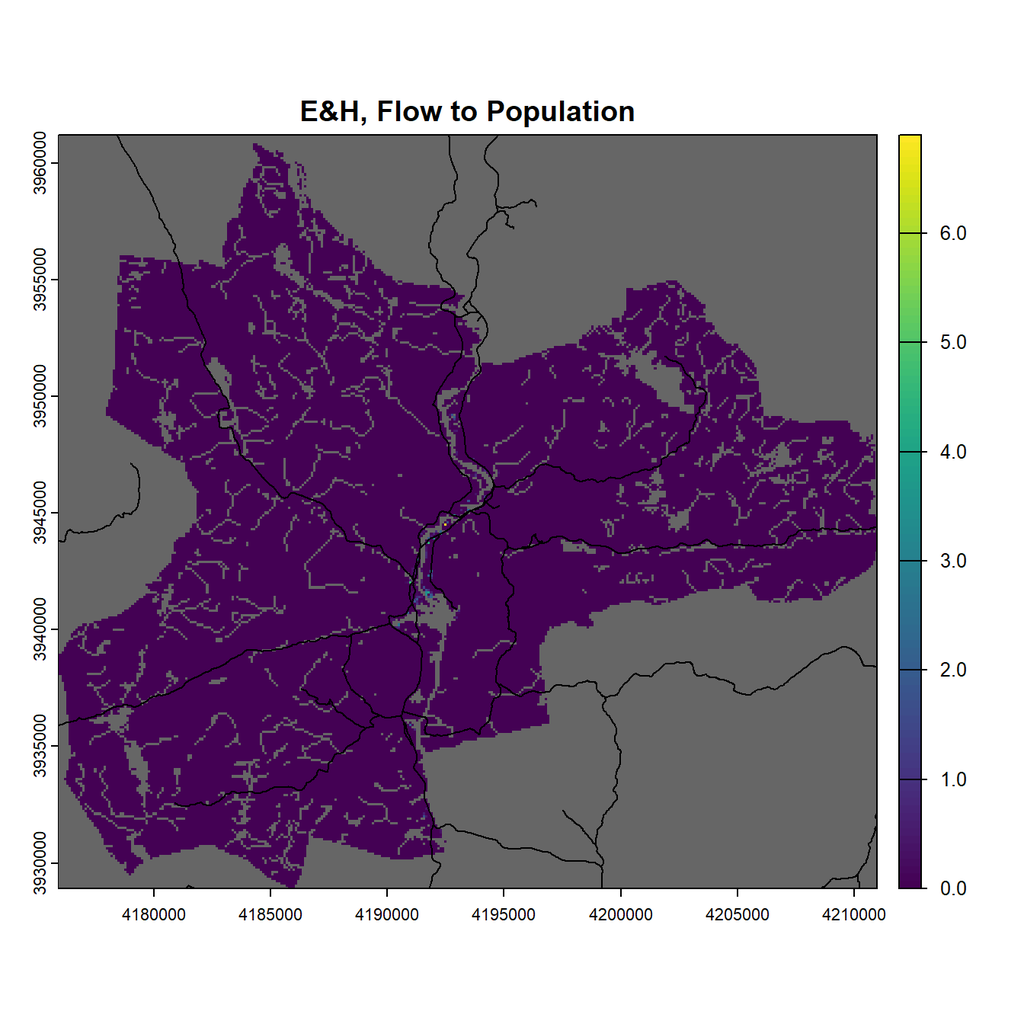

```r
plot(flow_d_pop %>% crop(ehs,mask=T),colNA="grey40", main = "E&H, Flow to Population")
plot(roads_t,add=T)
```

Print the table.

```r
kable(flow_df)
```

| provision_cat | demand_artif | demand_agric | demand_pop |
| --- | --- | --- | --- |
| artif | 99.22281 | 10.25137 | 608.3255 |
| agric | 274.33973 | 7420.61811 | 1856.9868 |
| natur | 4090.01798 | 8482.30696 | 21813.0601 |

# 6. Met and Unmet Demand

Unmet demand is equal to total demand minus provided service. We can express both as absolute and relative numbers. I just make some table for this.

```r
# I make a table of all
dem_df<-as.data.frame(matrix(ncol = 4,nrow=7))
colnames(dem_df)<-c("indicator","demand_artif","demand_agric","demand_pop")
dem_df$indicator<-c("total_demand","total_provided","unmet_demand","rel_prov_artif","rel_prov_agric","rel_prov_natur","rel_unmet")

dem_df$demand_artif[dem_df$indicator=="total_demand"]<-sum(values(sdam_artif),na.rm=T)
dem_df$demand_agric[dem_df$indicator=="total_demand"]<-sum(values(sdam_agric),na.rm=T)
dem_df$demand_pop[dem_df$indicator=="total_demand"]<-sum(values(sdam_pop),na.rm=T)

dem_df$demand_artif[dem_df$indicator=="total_provided"]<-sum(flow_df$demand_artif)
dem_df$demand_agric[dem_df$indicator=="total_provided"]<-sum(flow_df$demand_agric)
dem_df$demand_pop[dem_df$indicator=="total_provided"]<-sum(flow_df$demand_pop)

dem_df$demand_artif[dem_df$indicator=="unmet_demand"]<-dem_df$demand_artif[dem_df$indicator=="total_demand"] - dem_df$demand_artif[dem_df$indicator=="total_provided"]
dem_df$demand_agric[dem_df$indicator=="unmet_demand"]<-dem_df$demand_agric[dem_df$indicator=="total_demand"] - dem_df$demand_agric[dem_df$indicator=="total_provided"]
dem_df$demand_pop[dem_df$indicator=="unmet_demand"]<-dem_df$demand_pop[dem_df$indicator=="total_demand"] - dem_df$demand_pop[dem_df$indicator=="total_provided"]

dem_df$demand_artif[dem_df$indicator=="rel_prov_artif"]<-round(flow_df$demand_artif[flow_df$provision_cat=="artif"]/dem_df$demand_artif[dem_df$indicator=="total_demand"],digits=3)
dem_df$demand_agric[dem_df$indicator=="rel_prov_artif"]<-round(flow_df$demand_agric[flow_df$provision_cat=="artif"]/dem_df$demand_agric[dem_df$indicator=="total_demand"],digits=3)
dem_df$demand_pop[dem_df$indicator=="rel_prov_artif"]<-round(flow_df$demand_pop[flow_df$provision_cat=="artif"]/dem_df$demand_pop[dem_df$indicator=="total_demand"],digits=3)

dem_df$demand_artif[dem_df$indicator=="rel_prov_agric"]<-round(flow_df$demand_artif[flow_df$provision_cat=="agric"]/dem_df$demand_artif[dem_df$indicator=="total_demand"],digits=3)
dem_df$demand_agric[dem_df$indicator=="rel_prov_agric"]<-round(flow_df$demand_agric[flow_df$provision_cat=="agric"]/dem_df$demand_agric[dem_df$indicator=="total_demand"],digits=3)
dem_df$demand_pop[dem_df$indicator=="rel_prov_agric"]<-round(flow_df$demand_pop[flow_df$provision_cat=="agric"]/dem_df$demand_pop[dem_df$indicator=="total_demand"],digits=3)

dem_df$demand_artif[dem_df$indicator=="rel_prov_natur"]<-round(flow_df$demand_artif[flow_df$provision_cat=="natur"]/dem_df$demand_artif[dem_df$indicator=="total_demand"],digits=3)
dem_df$demand_agric[dem_df$indicator=="rel_prov_natur"]<-round(flow_df$demand_agric[flow_df$provision_cat=="natur"]/dem_df$demand_agric[dem_df$indicator=="total_demand"],digits=3)
dem_df$demand_pop[dem_df$indicator=="rel_prov_natur"]<-round(flow_df$demand_pop[flow_df$provision_cat=="natur"]/dem_df$demand_pop[dem_df$indicator=="total_demand"],digits=3)

dem_df$demand_artif[dem_df$indicator=="rel_unmet"]<-round(dem_df$demand_artif[dem_df$indicator=="unmet_demand"]/dem_df$demand_artif[dem_df$indicator=="total_demand"],digits=3)
dem_df$demand_agric[dem_df$indicator=="rel_unmet"]<-round(dem_df$demand_agric[dem_df$indicator=="unmet_demand"]/dem_df$demand_agric[dem_df$indicator=="total_demand"],digits=3)
dem_df$demand_pop[dem_df$indicator=="rel_unmet"]<-round(dem_df$demand_pop[dem_df$indicator=="unmet_demand"]/dem_df$demand_pop[dem_df$indicator=="total_demand"],digits=3)
```

Relevant to note here is that we use population number in case of demand category “pop” and we use cells in case of demand categories “artif” and “agric”. We may want to switch all to the count of cells. Then the respective result just has to be multiplied by the spatial size of each cell (each cell one hectare I believe).

```r
kable(dem_df)
```

| indicator | demand_artif | demand_agric | demand_pop |
| --- | --- | --- | --- |
| total_demand | 19665.000 | 43149.000 | 201232.706 |
| total_provided | 4463.581 | 15913.176 | 24278.372 |
| unmet_demand | 15201.419 | 27235.824 | 176954.334 |
| rel_prov_artif | 0.005 | 0.000 | 0.003 |
| rel_prov_agric | 0.014 | 0.172 | 0.009 |
| rel_prov_natur | 0.208 | 0.197 | 0.108 |
| rel_unmet | 0.773 | 0.631 | 0.879 |

And then let us add a few maps of unmet demand. Look at this for Evje and Hornnes

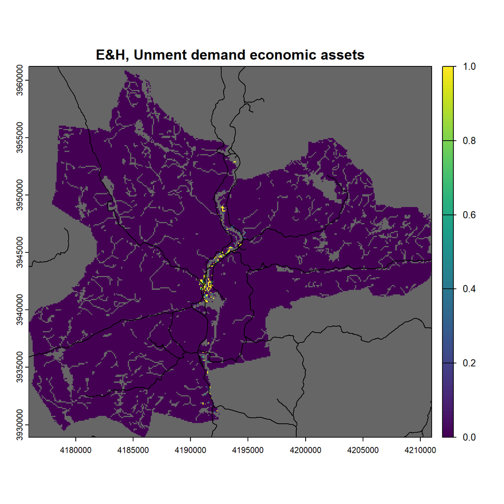

```r
unmet_d_artif<-sdam_artif - flow_d_artif_s_natur - flow_d_artif_s_agric - flow_d_artif_s_artif
unmet_d_agric<-sdam_agric - flow_d_agric_s_natur - flow_d_agric_s_agric - flow_d_agric_s_artif
unmet_d_econ <- unmet_d_artif + unmet_d_agric
unmet_d_pop<-sdam_pop - flow_d_pop_s_natur - flow_d_pop_s_agric - flow_d_pop_s_artif

plot(unmet_d_econ %>% crop(ehs,mask=T),colNA="grey40", main = "E&H, Unment demand economic assets")
plot(roads_t,add=T)
```

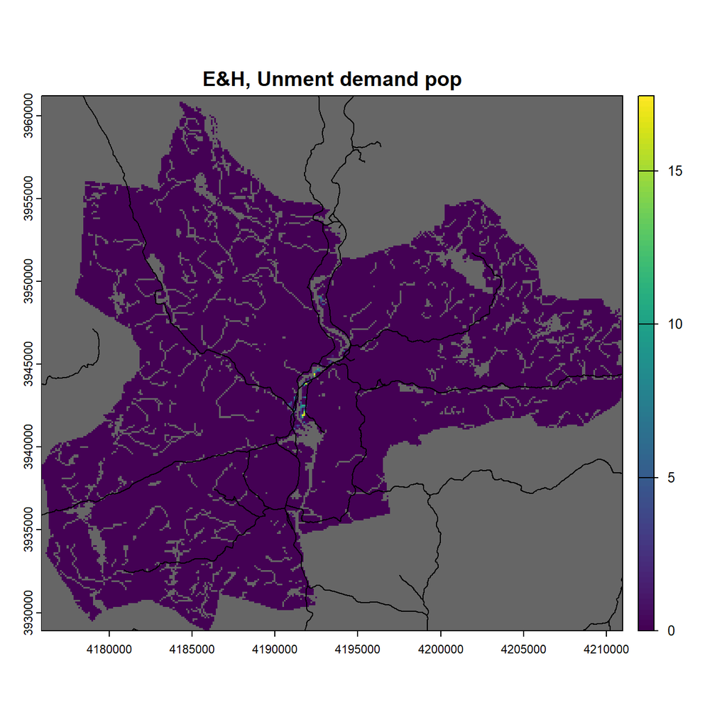

```r
plot(unmet_d_pop %>% crop(ehs,mask=T),colNA="grey40", main = "E&H, Unment demand pop")
plot(roads_t,add=T)
```

# 7. Supply and Use Tables

## 7.1 Supply Tables

First we make a land cover map showing the supply categories we want to report in. And we need to aggregate our flows.

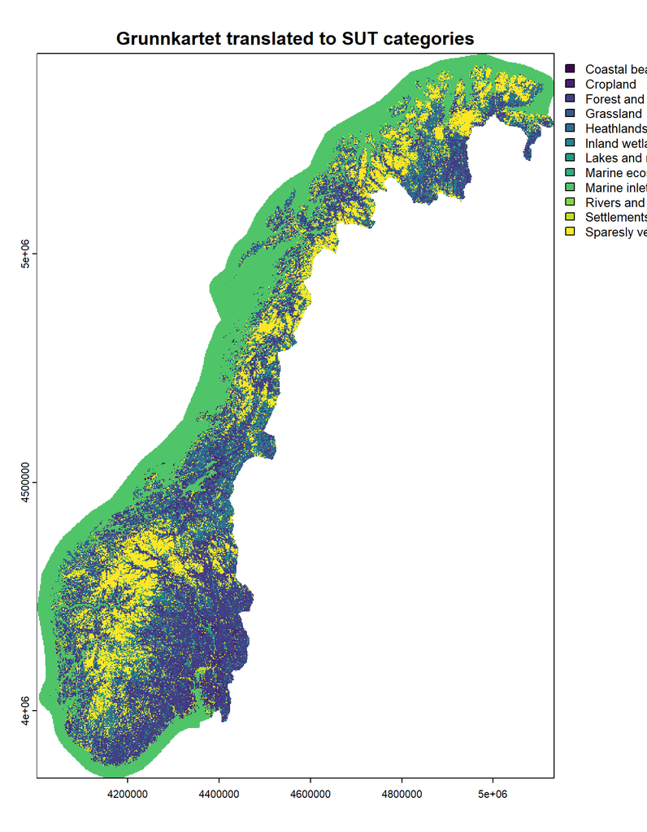

```r
# aggregate flows
flow_d_all_s_all<-flow_d_artif_s_artif+flow_d_artif_s_agric+flow_d_artif_s_natur+
  flow_d_agric_s_artif+flow_d_agric_s_agric+flow_d_agric_s_natur

# so first make the vector of ecosystem types
estv<-c("Settlements and other artificial areas",
        "Cropland",
        "Grassland",
        "Forest and woodlands",
        "Heathlands and shrub",
        "Sparesly vegetated ecosystems",
        "Inland wetlands",
        "Rivers and canals",
        "Lakes and reservoirs",
        "Marine inlets and transitional waters",
        "Coastal beaches, dunes and wetlands",
        "Marine ecosystems")

# and add it to our lcm_idf
lcm_idf['es_type']<-NA
lcm_idf$es_type[lcm_idf$landcover_id %in% c(100,111,112,121,130,131,132,133,134,135,141,142,152)]<-estv[1] # settlem
lcm_idf$es_type[lcm_idf$landcover_id %in% c(200)]<-estv[2] # cropl
lcm_idf$es_type[lcm_idf$landcover_id %in% c(310,320)]<-estv[3] # grassl
lcm_idf$es_type[lcm_idf$landcover_id %in% c(400,410,420,440)]<-estv[4] # forest
lcm_idf$es_type[lcm_idf$landcover_id %in% c(520)]<-estv[5] # bush
lcm_idf$es_type[lcm_idf$landcover_id %in% c(600,611,623,631)]<-estv[6] # sparse
lcm_idf$es_type[lcm_idf$landcover_id %in% c(720)]<-estv[7] # wetlands
lcm_idf$es_type[lcm_idf$landcover_id %in% c(810)]<-estv[8] # rivers
lcm_idf$es_type[lcm_idf$landcover_id %in% c(910)]<-estv[9] # lakes
lcm_idf$es_type[lcm_idf$landcover_id %in% c(1100)]<-estv[11] # coastal
lcm_idf$es_type[lcm_idf$landcover_id %in% c(1200)]<-estv[10] # marine inlets
lcm_idf$es_type[lcm_idf$landcover_id %in% c(9900)]<-estv[12] # marine ecosystems

# Call it lcm5, which follows the required classification
lcm5 <- terra::subst(lcm2,lcm_idf$landcover_id,lcm_idf$es_type)
terra::plot(lcm5, main="Grunnkartet translated to SUT categories")
```

We want to disaggregate the flows by NUTS2 region. So for this we need the individual NUTS2 shapes.

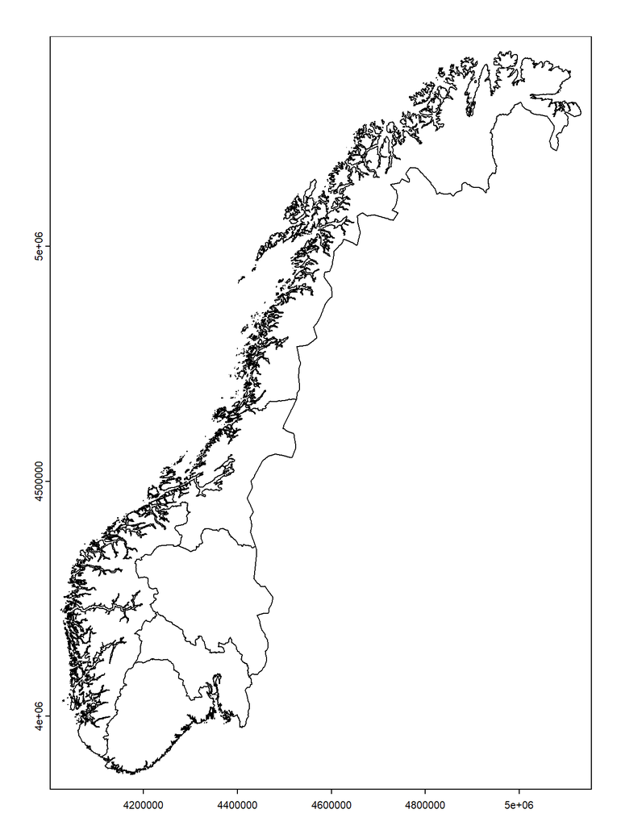

```r
n2shp<-terra::vect(file.path(dfp,"Norway_files","NUTS2021_NO_LVL2_wosvalbard","NUTS2021_NO_LVL2_wos.shp"))
n2shp <- project(n2shp,crs(lcm))
plot(n2shp)
```

Then we compute the flow of service provision for each of the ecosystem categories in each region of interest. We do this by allocating the total service flow across our ecosystems of interest. Allocation follows weights, and the computation of those is specified in the guidance note. I make a function for this, which we can feed with any shapefile of interest for area-specific results.

```r
# here is a function (written for easy debugging, not efficiency)

calc_es_flow_for_shp<-function(estv, # array of unique ecosystems
                               maskshp, # the area of interest as a spatial vector file
                               reflcm, # the reference land cover map
                               totalflowm, # the map of total service flows
                               refcnm # the map of reference curve number
){
  # Step 1: Crop and mask input data (if that is wanted)
  if(is.null(maskshp)){
    cnmc<-refcnm
    lcmc<-reflcm
    flowtc<-totalflowm
  } else {
    cnmc<-crop(refcnm,maskshp,mask=T)
    lcmc<-crop(reflcm,maskshp,mask=T)
    flowtc<-crop(totalflowm,maskshp,mask=T)
  }
  # Step 2: Make a vector of correction factors based on area-specific CN
  cfvc<-numeric()
  for(i in 1:length(estv)){
    cfvc[i]<-(100 - mean(cnmc[lcmc==estv[i]],na.rm=T))/100
  }
  # Step 3: Compute extent of each ecosystem
  exmc<-freq(lcmc)
  # Step 4: Move into one dataframe
  # then put all into one dataframe
  cfmc<-data.frame(cbind(estv,cfvc))
  dfwc<-cfmc %>% left_join(exmc,by=join_by(estv==value)) %>%
    slice(order(factor(estv, levels = estv))) %>%
    mutate(cfvc = as.numeric(cfvc))
  # Step 5: Compute weighted extents
  dfwc['weighted_ext']<-dfwc$count*dfwc$cfvc
  sswc<-sum(dfwc$weighted_ext,na.rm=T) # sum weighted
  # Step 6: Compute allocation coefficients
  dfwc['alloc_coeff']<-dfwc$weighted_ext/sswc
  # Step 7: Compute total flow for the area of interest
  totalflowc<-sum(values(flowtc),na.rm=T)
  # Step 8: Compute disaggregated flows
  dfwc['fc_flow']<-dfwc$alloc_coeff*totalflowc
  # Step 9: Put all into one table
  dfwtc <- dfwc %>% select(c(estv,fc_flow)) %>% rename(ecosystem = estv) %>%
    add_row(ecosystem = "Total",fc_flow = totalflowc, .before = 1)
  # Step 10: Return result
  return(dfwtc)
}
```

So then we compute our flood protection service flows disaggregated by ecosystem and area. The unit is ha of economic assets protected from potential flood damage. Population is not considered here.

```r
# Loop across our NUTS2 areas
sl<-list()
for(n in 1:length(unique(n2shp$NUTS_ID))){
  sl[[n]]<-calc_es_flow_for_shp(estv=estv,
                                maskshp = n2shp[n2shp$NUTS_ID == unique(n2shp$NUTS_ID)[n],],
                                reflcm = lcm5,
                                totalflowm = flow_d_all_s_all,
                                refcnm = cnm2[[4]])
  sl[[n]]['region'] <- unique(n2shp$NUTS_ID)[n]
}
# add for total country
ti<-length(sl)+1
sl[[ti]]<-calc_es_flow_for_shp(estv=estv,
                                         maskshp = NULL,
                                         reflcm = lcm5,
                                         totalflowm = flow_d_all_s_all,
                                         refcnm = cnm2[[4]])
sl[[ti]]['region'] <- "NO0"
# reformat to our final supply table
sdf<-do.call("rbind",sl) %>% pivot_wider(names_from = ecosystem,values_from = fc_flow) %>% arrange(region)
library(tidyr)
rm(sl,ti)
```

Here is the resulting supply table:

```r
kable(sdf)
```

| region | Total | Settlements and other artificial areas | Cropland | Grassland | Forest and woodlands | Heathlands and shrub | Sparesly vegetated ecosystems | Inland wetlands | Rivers and canals | Lakes and reservoirs | Marine inlets and transitional waters | Coastal beaches, dunes and wetlands | Marine ecosystems |
| --- | --- | --- | --- | --- | --- | --- | --- | --- | --- | --- | --- | --- | --- |
| NO0 | 20376.757 | 144.732064 | 412.78565 | 148.462720 | 10966.0123 | 4346.4904 | 3060.9589 | 1297.31490 | NaN | NaN | NaN | NaN | NaN |
| NO02 | 6197.159 | 44.627473 | 152.22266 | 37.608726 | 4050.0580 | 720.7046 | 740.0186 | 451.91886 | NaN | NaN | NaN | NaN | NaN |
| NO06 | 3222.366 | 18.227057 | 80.90486 | 18.389263 | 1685.6287 | 786.9721 | 244.9067 | 387.33685 | NaN | NaN | NaN | NaN | NaN |
| NO07 | 2458.078 | 7.135991 | 16.02332 | 6.815852 | 1024.6273 | 697.7799 | 543.9162 | 161.77929 | NaN | NaN | NaN | NaN | NaN |
| NO08 | 3105.884 | 53.048198 | 161.12521 | 21.475341 | 2311.0704 | 271.5092 | 156.3246 | 131.33072 | NaN | NaN | NaN | NaN | NaN |
| NO09 | 4120.989 | 39.830164 | 77.87190 | 17.452256 | 2940.4673 | 567.3142 | 329.4863 | 148.56733 | NaN | NaN | NaN | NaN | NaN |
| NO0A | 1253.880 | 11.669541 | 29.61766 | 26.725087 | 551.8796 | 336.4436 | 258.1943 | 39.34995 | NaN | NaN | NaN | NaN | NaN |

And here for our case study Evje and Hornnes

```r
ehsupply<-calc_es_flow_for_shp(estv=estv,
                           maskshp = ehs,
                           reflcm = lcm5,
                           totalflowm = flow_d_all_s_all,
                           refcnm = cnm2[[4]])
kable(ehsupply)
```

| ecosystem | fc_flow |
| --- | --- |
| Total | 118.9918641 |
| Settlements and other artificial areas | 0.8755518 |
| Cropland | 1.2114196 |
| Grassland | 0.5358213 |
| Forest and woodlands | 101.2785602 |
| Heathlands and shrub | 3.0976016 |
| Sparesly vegetated ecosystems | 3.2533411 |
| Inland wetlands | 8.7395686 |
| Rivers and canals | NaN |
| Lakes and reservoirs | NaN |
| Marine inlets and transitional waters | NaN |
| Coastal beaches, dunes and wetlands | NaN |
| Marine ecosystems | NaN |

## 7.2 Use Tables

For the time being we only report total use and we assume it goes to households.

```r
udf <- sdf %>%
  select(c(region,Total)) %>%
  mutate(`Intermediate consumption by industries` = NA) %>%
  mutate(`Government final consumption` = NA) %>%
  mutate(`Households final consumption` = Total) %>%
  mutate(`Gross capital formation` = NA) %>%
  mutate(Exports = NA)
```

And then here the resulting use table

```r
kable(udf)
```

| region | Total | Intermediate consumption by industries | Government final consumption | Households final consumption | Gross capital formation | Exports |
| --- | --- | --- | --- | --- | --- | --- |
| NO0 | 20376.757 | NA | NA | 20376.757 | NA | NA |
| NO02 | 6197.159 | NA | NA | 6197.159 | NA | NA |
| NO06 | 3222.366 | NA | NA | 3222.366 | NA | NA |
| NO07 | 2458.078 | NA | NA | 2458.078 | NA | NA |
| NO08 | 3105.884 | NA | NA | 3105.884 | NA | NA |
| NO09 | 4120.989 | NA | NA | 4120.989 | NA | NA |
| NO0A | 1253.880 | NA | NA | 1253.880 | NA | NA |

# 8. Ideas for Improvements

- Add street infrastructure from OSM to our artificial areas
- In section 2.2.2 we could revisit the hydrological soil type map, possibly using a more specific map for Norway. The one we are currently using has missing data in the North of Norway
- In section 2.2.3 we could revisit the CN lookup table. In its current form there are some categories missing, which means that our resulting potential runoff retention map has a quite a few “holes”, i.e. cells that cannot provide any flood control in our model, even though they probably do in reality. These categories are 9900 (uklassifisert), 1200 (marine økosystemer (uspesifisert)), 1100 (Kyststrender dyner og våtmark (uspesifisert)), 910 (Innsjøer og dammer), 810 (Elver og bekker), and 631 (Isbreer og varige snøfonner).
- In section 3 we could revisit the threshold definition for SPAs. While the current definition is clear and transparent, its scientific substance is unclear.
- In section 4 we could refine service demand, for example by changing to a different flood frequency or/and a different flood depth threshold.